## 2nd mid review

# Q1)

```python
import numpy as np
import pandas as pd
import matplotlib.pyplot as plt
```

```python
POP = pd.read_csv(r"C:\Users\Jae\Desktop\Econ 381\homework\midexam\population.csv", header = 0, names = ["Date", "POP"])
TFP = pd.read_csv(r"C:\Users\Jae\Desktop\Econ 381\homework\W07\TFP.csv", header = 0, names = ["Date", "TFP"])

Date_pop = np.array(POP["Date"], dtype = np.datetime64)
Date_tfp = np.array(TFP["Date"], dtype = np.datetime64)
print("2017/01/01:", POP['POP'][57])   ## 2017/01/01
print("2017/01/01:", TFP['TFP'][63])   ## 2017/01/01

n = (float(POP['POP'][57]) / float(POP['POP'][8]))**(1/50) - 1
g = (TFP['TFP'][63] / TFP['TFP'][14])**(1/50) - 1
print("n:", n)
print("g:", g)
print("population growth rate: ", '{:.4f}'. format(n))
print("TFP growth rate: ", '{:.4f}'. format(g))
```

```
2017/01/01: 205537500.00000000
2017/01/01: 1.0305346250534058
n: 0.011913794134144284
g: 0.005236162356891727
population growth rate:  0.0119
TFP growth rate:  0.0052
```

### Q2)

```python
s=0.1
d=0.06
alpha=0.33
l=0.01

k_star = (1 - l) * (s / (d + g + n))**(1 / (1 - alpha))
print(k_star)
print("k_star = "'{:.2f}'. format(k_star))
```

```
1.458112012665608
k_star = 1.46
```

### Q3)

```
reaching to the steady-state at 65 years with 0.01 difference to the steady-state.
```

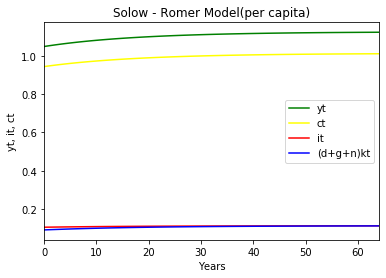

```python
# 3 - 1

K0=1000
L0=500
A0=1.7

def L(L0, n, time):
    return L0 * (1 + n)**(time)

def A(A0, g, time):
    return A0 * (1 + g)**(time)

def output_per_person(l, alpha, capital_per_person):
    return  pow(capital_per_person, alpha) * pow(1- l, 1- alpha)

def sr_function_output(l, K, alpha, A, L):
    return pow(1- l, 1 - alpha) * pow(K, alpha) * pow(A, 1 - alpha) * pow(L, 1 - alpha)

time = 0
population = [L0]
knowledge = [A0]
capital = [K0]
capital_p = [capital[0] / (knowledge[0] * population[0])]
output = [sr_function_output(l, capital[0], alpha, knowledge[0], population[0])]
output_p = [output_per_person(l, alpha, capital_p[0])]
investment = [s * output[0]]
investment_p = [s * output_p[0]]
depreciation = [(d + g + n) * capital[0]]
depreciation_p = [(d + g + n) * capital_p[0]]
consumption = [output[0] - investment[0]]
consumption_p = [output_p[0] - investment_p[0]]
change_in_capital = [investment[0] - depreciation[0]]
change_in_capital_p = [investment_p[0] - depreciation_p[0]]
i = 0

while (abs(k_star - capital_p[i])) > 0.01:
    i += 1
    time = np.append(time, i)
    population = np.append(population, L(L0, n, time[i]))    # population[i - 1] * (1 + n)
    knowledge = np.append(knowledge, A(A0, g, time[i]))  # knowledge[i - 1] * (1 + g)
    capital_p = np.append(capital_p, capital_p[i - 1] + change_in_capital_p[i - 1])
    output_p = np.append(output_p, output_per_person(l, alpha, capital_p[i]))
    investment_p = np.append(investment_p, s * output_p[i])
    depreciation_p = np.append(depreciation_p, (d + g + n) * capital_p[i])
    consumption_p = np.append(consumption_p, output_p[i] - investment_p[i])
    change_in_capital_p = np.append(change_in_capital_p, investment_p[i] - depreciation_p[i])

print("reaching to the steady-state at", len(time), "years with 0.01 difference to the steady-state.")
plt.plot(time, output_p, 'green', label = 'yt')
plt.plot(time, consumption_p, 'yellow', label = 'ct')
plt.plot(time, investment_p, 'red', label = 'it')
plt.plot(time, depreciation_p, 'blue', label = '(d+g+n)kt')
plt.title("Solow - Romer Model(per capita)")
plt.xlabel("Years")
plt.ylabel("yt, it, ct")
plt.xlim(0,i)
plt.legend()
plt.show()
```

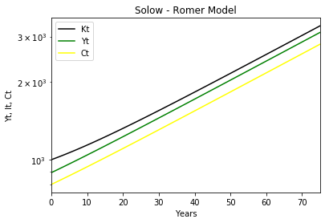

```python
# 3 - 2

time = 0
population = [L0]
knowledge = [A0]
capital = [K0]
output = [sr_function_output(l, capital[0], alpha, knowledge[0], population[0])]
investment = [s * output[0]]
depreciation = [(d + g + n) * capital[0]]
consumption = [output[0] - investment[0]]
change_in_capital = [investment[0] - depreciation[0]]
k_star = [capital[0]/(knowledge[0] * population[0])]
i = 0

for i in range(0, 75):
    i += 1
    time = np.append(time, i)
    population = np.append(population, L(L0, n, time[i]))
    knowledge = np.append(knowledge, A(A0, g, time[i]))
    capital = np.append(capital, capital[i - 1] + change_in_capital[i - 1])
    output = np.append(output, sr_function_output(l, capital[i], alpha, knowledge[i], population[i]))
    investment = np.append(investment, s * output[i])
    depreciation = np.append(depreciation, (d + g + n) * capital[i])
    consumption = np.append(consumption, output[i] - investment[i])
    change_in_capital = np.append(change_in_capital, investment[i] - depreciation[i])
    k_star = np.append(k_star, capital[i]/(knowledge[i]*population[i]))

plt.plot(time, capital, 'black', label = 'Kt')
plt.plot(time, output, 'green', label = 'Yt')
plt.plot(time, consumption, 'yellow', label = 'Ct')
plt.title("Solow - Romer Model")
plt.xlabel("Years")
plt.ylabel("Yt, It, Ct")
plt.yscale("log")
plt.xlim(0,i)
plt.legend()
plt.show()
```

```python
# 3 - 3

print("capital at steady-state:", capital[65])
print("population at steady-state:", population[65])
print("knowledge at steady-state:", knowledge[65])
```

```
capital at steady-state: 2786.2237744698423
population at steady-state: 1079.6886924106086
knowledge at steady-state: 2.3871276837352613
```

### review for Q3)

```
Years to reach steady state:  75 years
Capital at steady state: 4358.38
Labor at steady state: 1201.13
Knowledge at steady state: 2.50
```

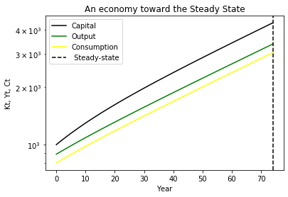

```python
def RS (l, A, K, L, a):
    return (((1 - l) ** (1 - a)) * (A ** (1 - a)) * (K ** a) * (L ** (1 - a)))

K0 = 1000
L0 = 500
A0 = 1.7
s=0.1
d=0.06
alpha=0.33
l=0.01

Capital = [K0]
Labor = [L0]
Knowledge = [A0]
Output = [RS(l, Knowledge[0], Capital[0], Labor[0], alpha)]
Consumption = [(1 - s) * Output[0]]
k = [Capital[0] / (Knowledge[0] * Labor[0])]
i = 0
time = 0

while abs(k[i] - 1.46) > 0.01:
    Capital= np.append(Capital, Capital[i] + (s * Output[i] - d * Capital[i]))
    Labor= np.append(Labor, Labor[i] * (1 + n))
    Knowledge= np.append(Knowledge, Knowledge[i] * (1 + g))
    Output= np.append(Output, RS(l, Knowledge[i + 1], Capital[i + 1], Labor[i + 1], alpha))
    Consumption= np.append(Consumption, (1 - s) * Output[i + 1])
    k= np.append(k, Capital[i + 1] / (Knowledge[i + 1] * Labor[i + 1]))
    i += 1
    time = np.append(time, i)

print("Years to reach steady state: ", len(time),"years")
print("Capital at steady state: {:.2f}" .format(Capital[-1]))
print("Labor at steady state: {:.2f}" .format(Labor[-1]))
print("Knowledge at steady state: {:.2f}" .format(Knowledge[-1]))

plt.plot(time, Capital,c= "black", label = "Capital")
plt.plot(time, Output, c="green", label = "Output")
plt.plot(time, Consumption, c= "yellow", label = "Consumption")
plt.axvline(x = i, color = "black", linestyle = "--", label = " Steady-state")
plt.title("An economy toward the Steady State")
plt.yscale('log')
plt.xlabel("Year")
plt.ylabel("Kt, Yt, Ct")
plt.legend()
plt.show()
```

## Q4)

```
k_star_new = 4.102885421661664
reaching the the new k_star takes  183 years with 1.0652 value difference to the new steady-state
```

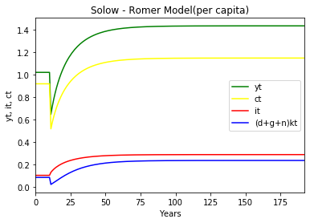

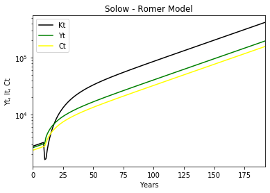

```python
# 4 - 1
# years need to reach to the new k_star

def L(L0, n, time):
    return L0 * (1 + n)**(time)

def A(A0, g, time):
    return A0 * (1 + g)**(time)

s = 0.1
d = 0.06
alpha = 0.33
l = 0.01
K1 = capital[65]
L1 = population[65]
A1 = knowledge[65]

time = 0
population1 = [L1]
knowledge1 = [A1]
capital1 = [K1]
capital_p1 = [capital1[0] / (knowledge1[0] * population1[0])]
output1 = [sr_function_output(l, capital1[0], alpha, knowledge1[0], population1[0])]
output_p1 = [output_per_person(l, alpha, capital_p1[0])]
investment1 = [s * output1[0]]
investment_p1 = [s * output_p1[0]]
depreciation1 = [(d + g + n) * capital1[0]]
depreciation_p1 = [(d + g + n) * capital_p1[0]]
consumption1 = [output1[0] - investment1[0]]
consumption_p1 = [output_p1[0] - investment_p1[0]]
change_in_capital1 = [investment1[0] - depreciation1[0]]
change_in_capital_p1 = [investment_p1[0] - depreciation_p1[0]]
i = 0

for i in range(0, 10):
    i += 1
    time = np.append(time, i)
    population1 = np.append(population1, L(L1, n, time[i]))
    knowledge1 = np.append(knowledge1, A(A1, g, time[i]))
    capital1 = np.append(capital1, capital1[i - 1] + change_in_capital1[i - 1])
    capital_p1 = np.append(capital_p1, capital1[i] / (knowledge1[i] * population1[i]))
    output1 = np.append(output1, sr_function_output(l, capital1[i], alpha, knowledge1[i], population1[i]))
    output_p1 = np.append(output_p1, output_per_person(l, alpha, capital_p1[i]))
    investment1 = np.append(investment1, s * output1[i])
    investment_p1 = np.append(investment_p1, s * output_p1[i])
    depreciation1 = np.append(depreciation1, (d + g + n) * capital1[i])
    depreciation_p1 = np.append(depreciation_p1, (d + g + n) * capital_p1[i])
    consumption1 = np.append(consumption1, output1[i] - investment1[i])
    consumption_p1 = np.append(consumption_p1, output_p1[i] - investment_p1[i])
    change_in_capital1 = np.append(change_in_capital1, investment1[i] - depreciation1[i])

capital1[10] = (capital1[9] / 2)
s2 = s * 2
A2 = knowledge1[10] * 2
k_star_new = (1 - l) * (s2 / (d + g + n))**(1/ (1 - alpha))
print("k_star_new =", k_star_new)

while (abs(k_star_new - capital_p1[i])) > 1.0652:
    i += 1
    time = np.append(time, i)
    population1 = np.append(population1, L(L1, n, time[i]))
    knowledge1 = np.append(knowledge1, A(A2, g, time[i - 10]))
    capital1 = np.append(capital1, capital1[i - 1] + change_in_capital1[i - 1])
    capital_p1 = np.append(capital_p1, capital1[i] / (knowledge1[i] * population1[i]))
    output1 = np.append(output1, sr_function_output(l, capital1[i], alpha, knowledge1[i], population1[i]))
    output_p1 = np.append(output_p1, output_per_person(l, alpha, capital_p1[i]))
    investment1 = np.append(investment1, s2 * output1[i])
    investment_p1 = np.append(investment_p1, s2 * output_p1[i])
    depreciation1 = np.append(depreciation1, (d + g + n) * capital1[i])
    depreciation_p1 = np.append(depreciation_p1, (d + g + n) * capital_p1[i])
    consumption1 = np.append(consumption1,output1[i] - investment1[i])
    consumption_p1 = np.append(consumption_p1, output_p1[i] - investment_p1[i])
    change_in_capital1 = np.append(change_in_capital1, investment1[i] - depreciation1[i])

print("reaching the the new k_star takes ", len(time) - 10, "years with 1.0652 value difference to the new steady-state")

plt.plot(time, output_p1, 'green', label = 'yt')
plt.plot(time, consumption_p1, 'yellow', label = 'ct')
plt.plot(time, investment_p1, 'red', label = 'it')
plt.plot(time, depreciation_p1, 'blue', label = '(d+g+n)kt')
plt.title("Solow - Romer Model(per capita)")
plt.xlabel("Years")
plt.ylabel("yt, it, ct")
plt.xlim(0,i)
plt.legend()
plt.show()

plt.plot(time, capital1, 'black', label = 'Kt')
plt.plot(time, output1, 'green', label = 'Yt')
plt.plot(time, consumption1, 'yellow', label = 'Ct')
plt.title("Solow - Romer Model")
plt.xlabel("Years")
plt.ylabel("Yt, It, Ct")
plt.yscale("log")
plt.xlim(0,i)
plt.legend()
plt.show()
```

I tried to put all three changes

### review for Q4)

### case 1

```
new steady-state: 1.46
Years to reach steady state:  101 years
Capital at steady state: 6782.92
Labor at steady state: 1634.26
Knowledge at steady state: 2.87
```

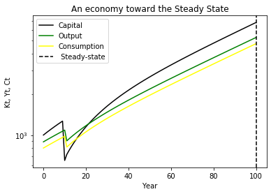

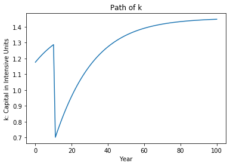

```python
def RS (l, A, K, L, a):
    return (((1 - l) ** (1 - a)) * (A ** (1 - a)) * (K ** a) * (L ** (1 - a)))

K0 = 1000
L0 = 500
A0 = 1.7
s=0.1
d=0.06
alpha=0.33
l=0.01

Capital = [K0]
Labor = [L0]
Knowledge = [A0]
Output = [RS(l, Knowledge[0], Capital[0], Labor[0], alpha)]
Consumption = [(1 - s) * Output[0]]
k = [Capital[0] / (Knowledge[0] * Labor[0])]
i = 0
time = 0

for i in range(0, 10):
    Capital= np.append(Capital, Capital[i] + (s * Output[i] - d * Capital[i]))
    Labor= np.append(Labor, Labor[i] * (1 + n))
    Knowledge= np.append(Knowledge, Knowledge[i] * (1 + g))
    Output= np.append(Output, RS(l, Knowledge[i + 1], Capital[i + 1], Labor[i + 1], alpha))
    Consumption= np.append(Consumption, (1 - s) * Output[i + 1])
    k= np.append(k, Capital[i + 1] / (Knowledge[i + 1] * Labor[i + 1]))
    i += 1
    time = np.append(time, i)

Capital[i] = Capital[i] / 2
new_k = (1 - l) * (s / (d + g + n))**(1 / (1 - alpha))

while abs(k[i] - new_k) > 0.01:
    Capital= np.append(Capital, Capital[i] + (s * Output[i] - d * Capital[i]))
    Labor= np.append(Labor, Labor[i] * (1 + n))
    Knowledge= np.append(Knowledge, Knowledge[i] * (1 + g))
    Output= np.append(Output, RS(l, Knowledge[i + 1], Capital[i + 1], Labor[i + 1], alpha))
    Consumption= np.append(Consumption, (1 - s) * Output[i + 1])
    k= np.append(k, Capital[i + 1] / (Knowledge[i + 1] * Labor[i + 1]))
    i += 1
    time = np.append(time, i)

print("new steady-state: {:.2f}".format(new_k))
print("Years to reach steady state: ", len(time), "years")
print("Capital at steady state: {:.2f}" .format(Capital[-1]))
print("Labor at steady state: {:.2f}" .format(Labor[-1]))
print("Knowledge at steady state: {:.2f}" .format(Knowledge[-1]))

plt.plot(time, Capital,c= "black", label = "Capital")
plt.plot(time, Output, c="green", label = "Output")
plt.plot(time, Consumption, c= "yellow", label = "Consumption")
plt.axvline(x = i, color = "black", linestyle = "--", label = " Steady-state")
plt.title("An economy toward the Steady State")
plt.yscale('log')
plt.xlabel("Year")
plt.ylabel("Kt, Yt, Ct")
plt.legend()
plt.show()

plt.plot(time, k)
plt.xlabel("Year")
plt.ylabel("k: Capital in Intensive Units")
plt.title("Path of k")
plt.show()
```

### case 2

```
new steady-state: 4.10
Years to reach steady state:  136 years
Capital at steady state: 34836.49
Labor at steady state: 2473.69
Knowledge at steady state: 3.44
```

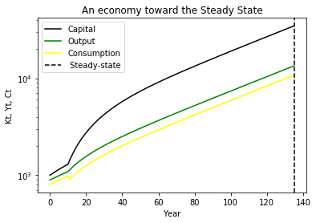

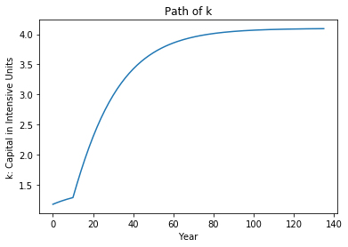

```python
def RS (l, A, K, L, a):
    return (((1 - l) ** (1 - a)) * (A ** (1 - a)) * (K ** a) * (L ** (1 - a)))

K0 = 1000
L0 = 500
A0 = 1.7
s=0.1
d=0.06
alpha=0.33
l=0.01

Capital = [K0]
Labor = [L0]
Knowledge = [A0]
Output = [RS(l, Knowledge[0], Capital[0], Labor[0], alpha)]
Consumption = [(1 - s) * Output[0]]
k = [Capital[0] / (Knowledge[0] * Labor[0])]
i = 0
time = 0

for i in range(0, 10):
    Capital= np.append(Capital, Capital[i] + (s * Output[i] - d * Capital[i]))
    Labor= np.append(Labor, Labor[i] * (1 + n))
    Knowledge= np.append(Knowledge, Knowledge[i] * (1 + g))
    Output= np.append(Output, RS(l, Knowledge[i + 1], Capital[i + 1], Labor[i + 1], alpha))
    Consumption= np.append(Consumption, (1 - s) * Output[i + 1])
    k= np.append(k, Capital[i + 1] / (Knowledge[i + 1] * Labor[i + 1]))
    i += 1
    time = np.append(time, i)

s2 = s * 2
new_k = (1 - l) * (s2 / (d + g + n))**(1 / (1 - alpha))

while abs(k[i] - new_k) > 0.01:
    Capital= np.append(Capital, Capital[i] + (s2 * Output[i] - d * Capital[i]))
    Labor= np.append(Labor, Labor[i] * (1 + n))
    Knowledge= np.append(Knowledge, Knowledge[i] * (1 + g))
    Output= np.append(Output, RS(l, Knowledge[i + 1], Capital[i + 1], Labor[i + 1], alpha))
    Consumption= np.append(Consumption, (1 - s2) * Output[i + 1])
    k= np.append(k, Capital[i + 1] / (Knowledge[i + 1] * Labor[i + 1]))
    i += 1
    time = np.append(time, i)

print("new steady-state: {:.2f}".format(new_k))
print("Years to reach steady state: ", len(time), "years")
print("Capital at steady state: {:.2f}" .format(Capital[-1]))
print("Labor at steady state: {:.2f}" .format(Labor[-1]))
print("Knowledge at steady state: {:.2f}" .format(Knowledge[-1]))

plt.plot(time, Capital,c= "black", label = "Capital")
plt.plot(time, Output, c="green", label = "Output")
plt.plot(time, Consumption, c= "yellow", label = "Consumption")
plt.axvline(x = i, color = "black", linestyle = "--", label = " Steady-state")
plt.title("An economy toward the Steady State")
plt.yscale('log')
plt.xlabel("Year")
plt.ylabel("Kt, Yt, Ct")
plt.legend()
plt.show()

plt.plot(time, k)
plt.xlabel("Year")
plt.ylabel("k: Capital in Intensive Units")
plt.title("Path of k")
plt.show()
```

### case 3

```
new steady-state: 1.46
Years to reach steady state:  103 years
Capital at steady state: 14038.85
Labor at steady state: 1673.43
Knowledge at steady state: 5.79
```

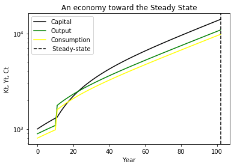

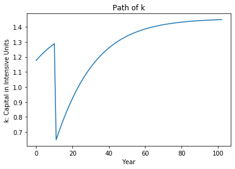

```python
def RS (l, A, K, L, a):
    return (((1 - l) ** (1 - a)) * (A ** (1 - a)) * (K ** a) * (L ** (1 - a)))

K0 = 1000
L0 = 500
A0 = 1.7
s=0.1
d=0.06
alpha=0.33
l=0.01

Capital = [K0]
Labor = [L0]
Knowledge = [A0]
Output = [RS(l, Knowledge[0], Capital[0], Labor[0], alpha)]
Consumption = [(1 - s) * Output[0]]
k = [Capital[0] / (Knowledge[0] * Labor[0])]
i = 0
time = 0

for i in range(0, 10):
    Capital= np.append(Capital, Capital[i] + (s * Output[i] - d * Capital[i]))
    Labor= np.append(Labor, Labor[i] * (1 + n))
    Knowledge= np.append(Knowledge, Knowledge[i] * (1 + g))
    Output= np.append(Output, RS(l, Knowledge[i + 1], Capital[i + 1], Labor[i + 1], alpha))
    Consumption= np.append(Consumption, (1 - s) * Output[i + 1])
    k= np.append(k, Capital[i + 1] / (Knowledge[i + 1] * Labor[i + 1]))
    i += 1
    time = np.append(time, i)

Knowledge[i] = Knowledge[i] * 2
new_k = (1 - l) * (s / (d + g + n))**(1 / (1 - alpha))

while abs(k[i] - new_k) > 0.01:
    Capital= np.append(Capital, Capital[i] + (s * Output[i] - d * Capital[i]))
    Labor= np.append(Labor, Labor[i] * (1 + n))
    Knowledge= np.append(Knowledge, Knowledge[i] * (1 + g))
    Output= np.append(Output, RS(l, Knowledge[i + 1], Capital[i + 1], Labor[i + 1], alpha))
    Consumption= np.append(Consumption, (1 - s) * Output[i + 1])
    k= np.append(k, Capital[i + 1] / (Knowledge[i + 1] * Labor[i + 1]))
    i += 1
    time = np.append(time, i)

print("new steady-state: {:.2f}".format(new_k))
print("Years to reach steady state: ", len(time), "years")
print("Capital at steady state: {:.2f}" .format(Capital[-1]))
print("Labor at steady state: {:.2f}" .format(Labor[-1]))
print("Knowledge at steady state: {:.2f}" .format(Knowledge[-1]))

plt.plot(time, Capital,c= "black", label = "Capital")
plt.plot(time, Output, c="green", label = "Output")
plt.plot(time, Consumption, c= "yellow", label = "Consumption")
plt.axvline(x = i, color = "black", linestyle = "--", label = " Steady-state")
plt.title("An economy toward the Steady State")
plt.yscale('log')
plt.xlabel("Year")
plt.ylabel("Kt, Yt, Ct")
plt.legend()
plt.show()

plt.plot(time, k)
plt.xlabel("Year")
plt.ylabel("k: Capital in Intensive Units")
plt.title("Path of k")
plt.show()
```

### case 4: everythings happened at the same time

```
new steady-state: 4.10
Years to reach steady state:  144 years
Capital at steady state: 79862.83
Labor at steady state: 2719.52
Knowledge at steady state: 7.17
```

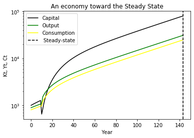

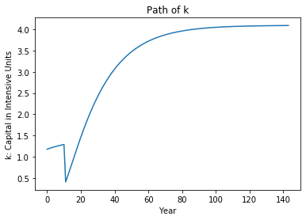

```python
def RS (l, A, K, L, a):
    return (((1 - l) ** (1 - a)) * (A ** (1 - a)) * (K ** a) * (L ** (1 - a)))

K0 = 1000
L0 = 500
A0 = 1.7
s=0.1
d=0.06
alpha=0.33
l=0.01

Capital = [K0]
Labor = [L0]
Knowledge = [A0]
Output = [RS(l, Knowledge[0], Capital[0], Labor[0], alpha)]
Consumption = [(1 - s) * Output[0]]
k = [Capital[0] / (Knowledge[0] * Labor[0])]
i = 0
time = 0

for i in range(0, 10):
    Capital= np.append(Capital, Capital[i] + (s * Output[i] - d * Capital[i]))
    Labor= np.append(Labor, Labor[i] * (1 + n))
    Knowledge= np.append(Knowledge, Knowledge[i] * (1 + g))
    Output= np.append(Output, RS(l, Knowledge[i + 1], Capital[i + 1], Labor[i + 1], alpha))
    Consumption= np.append(Consumption, (1 - s) * Output[i + 1])
    k= np.append(k, Capital[i + 1] / (Knowledge[i + 1] * Labor[i + 1]))
    i += 1
    time = np.append(time, i)

Capital[i] = Capital[i] / 2
s2 = s * 2
Knowledge[i] = Knowledge[i] * 2
new_k = (1 - l) * (s2 / (d + g + n))**(1 / (1 - alpha))

while abs(k[i] - new_k) > 0.01:
    Capital= np.append(Capital, Capital[i] + (s2 * Output[i] - d * Capital[i]))
    Labor= np.append(Labor, Labor[i] * (1 + n))
    Knowledge= np.append(Knowledge, Knowledge[i] * (1 + g))
    Output= np.append(Output, RS(l, Knowledge[i + 1], Capital[i + 1], Labor[i + 1], alpha))
    Consumption= np.append(Consumption, (1 - s2) * Output[i + 1])
    k= np.append(k, Capital[i + 1] / (Knowledge[i + 1] * Labor[i + 1]))
    i += 1
    time = np.append(time, i)

print("new steady-state: {:.2f}".format(new_k))
print("Years to reach steady state: ", len(time), "years")
print("Capital at steady state: {:.2f}" .format(Capital[-1]))
print("Labor at steady state: {:.2f}" .format(Labor[-1]))
print("Knowledge at steady state: {:.2f}" .format(Knowledge[-1]))

plt.plot(time, Capital,c= "black", label = "Capital")
plt.plot(time, Output, c="green", label = "Output")
plt.plot(time, Consumption, c= "yellow", label = "Consumption")
plt.axvline(x = i, color = "black", linestyle = "--", label = " Steady-state")
plt.title("An economy toward the Steady State")
plt.yscale('log')
plt.xlabel("Year")
plt.ylabel("Kt, Yt, Ct")
plt.legend()
plt.show()

plt.plot(time, k)
plt.xlabel("Year")
plt.ylabel("k: Capital in Intensive Units")
plt.title("Path of k")
plt.show()
```

## Q5)

The new steady-state is larger than the old steady-state. To reach to the new steady-state takes 183 years with the 1.0652 value difference to the new steady-state. Capital became smaller which makes output per person lower than the old steady-state. The saving rate got doubled, which makes poor right now. Knowledge doubled which makes growth faster. In the beginning the economy output per person will be lower than old steady-state output per person, but the economy will grow faster and become slower when it is about to reach to the new steady-state. Eventually, the economy will grow to the larger new steady-state than the old steady-state and output per person, consumption, and depreciation are larger than old steady-state.

### review for Q5)

Steady-state formula is (1 - l)(s / (d + g + n))**(1 / (1 - alpha)). If any of the formula's parameter changes, the steady-state changes.

The third case is about doubling the knowledge. The knowledge is not related to the steady-state, so the steady-state level is same as before. But knowledge is related to capital per person which make capital per person into half. Knowledge is also related to the output, capital and consumption, so the level of these three increases. Becuase the economy is below the steady-state, the economy will grow fast in the beginning.

Capital became a half, savings became doubled, knowledge became doubled. Because the economy is really below the steady-state, the economy will grow really fast for a long time and will reach to the higher steady state. The people at 10 years will have hard time to live.